# EjerciciosModelos

Cassandra Ramírez Monge

2022-12-02

2.8 El registro de varvas glaciales representado en figura 2.6. exhibe cierta no estariedad que puede mejorarse mediante la tranformación a logaritmos y alguna no estacionariedad adicional que puede corregirse diferenciando los logaritmos.

1. Argumente que la serie de varvas glaciales, digamos xt, muestra heteroscedasticidad al calcular la varianza de la muestra sobre la primera mitad y la segunda mitad de los datos. Argumente que la transformación yt=logxt estabiliza la varianza sobre la serie. Trace los histogramas de xt e yt para ver si la aproximacion a la normalidad mejora al transformar los datos.

```r
varv1 = varve[1:317]
varv2 = varve[318:634]
var(varv1) # = 133.4574
```

```
## [1] 133.4574
```

```r
var(varv2) # = 594.4904
```

```
## [1] 594.4904
```

```r
var(log(varv1)) # = 0.2707217
```

```
## [1] 0.2707217
```

```r
var(log(varv2)) # = 0.451371
```

```
## [1] 0.451371
```

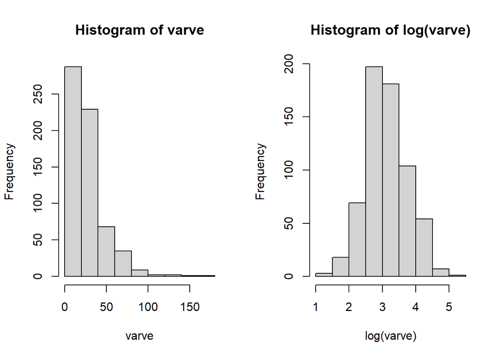

```r
par(mfrow=c(1,2))
hist(varve)
hist(log(varve))
```

La varianza en la segunda mitad de la serie de varvas es obviamente mayor que la de la primera mitad. Dividiendo los datos por la mitad da $\hat{\gamma} _x(0)= 133, 594$ para la primera y segunda parte respectivamente y la varianza es aproximadamente 4,5 veces mayor en la segunda mitad. La serie transformada $\gamma _t = ln x_t$ tiene $\hat{\gamma} _y(0) = .27, .45$ para las dos mitades, respectivamente, y la varianza de la segunda mitad es solo alrededor de 1.7 veces mayor.

Los histogramas, calculados para las dos series de la figura 2.1, indican que la transformación mejora la aproximación normal.

2. Trace la serie yt. ¿Existen intervalos de tiempo, del orden de 100 años, en los que se pueda observar un comportamiento comparable al observado en los registros de temperatura global de la figura 1.2?

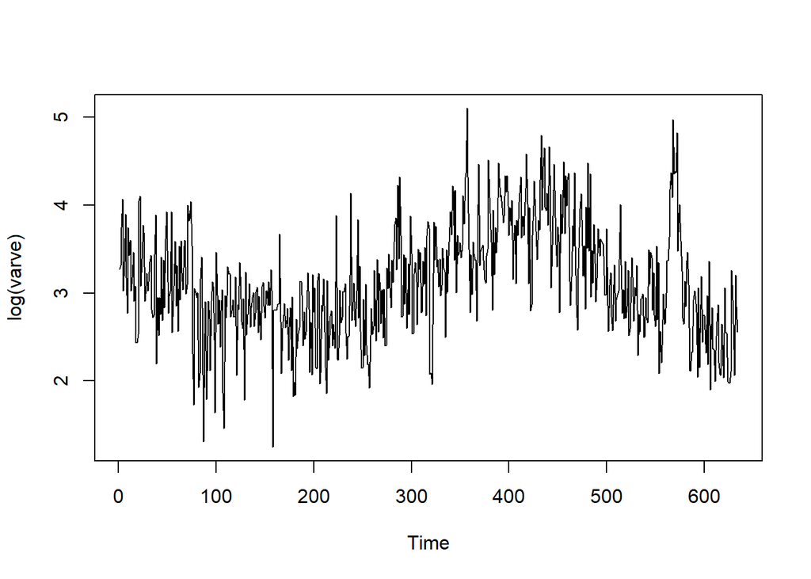

```r
plot(log(varve)) # for part (b)
```

Los datos entre 300 y 450 muestran una tendencia positiva similar a los datos de temperatura global. (Presumiblemente, esto se debe a una diferencia en la rotación de la Tierra).

3. Examine la muestra ACF de yt y comente.

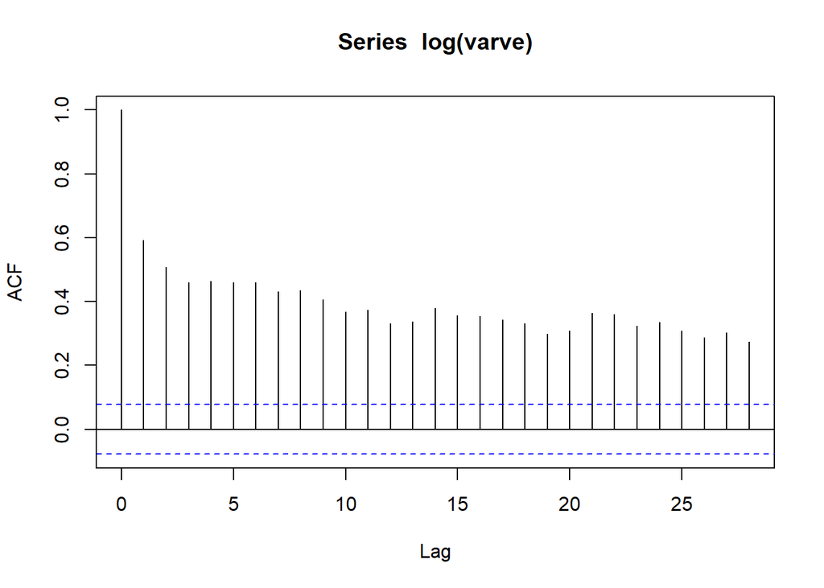

```r
acf(log(varve)) # for part (c)
```

El ACF de $y_t$ es positivo para una gran cantidad de rezagos y disminuye de forma lineal

(d)Calculela diferencia $u_t = y_t - 1$, examine su gráfico de tiempo y muestre ACF, y argumente que la diferenciación de los datos de varva registrados produce una serie razonablemente estacionaria. ¿ Puedes pensar en una interpretación prácticapara $u_t$? Hint: Para $|p|$ cerrada en cero, $log(1+p) \approx p$; sea $p= (y_t - y_{t-1})/ y_{t-1}$

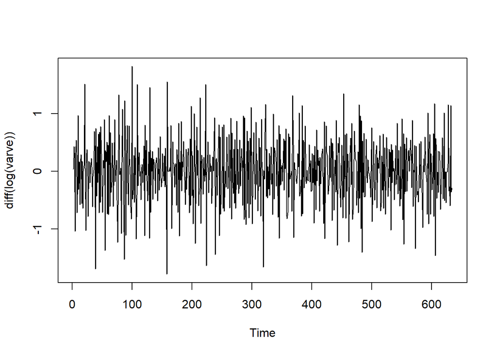

```r
plot(diff(log(varve))) # for part (d)
```

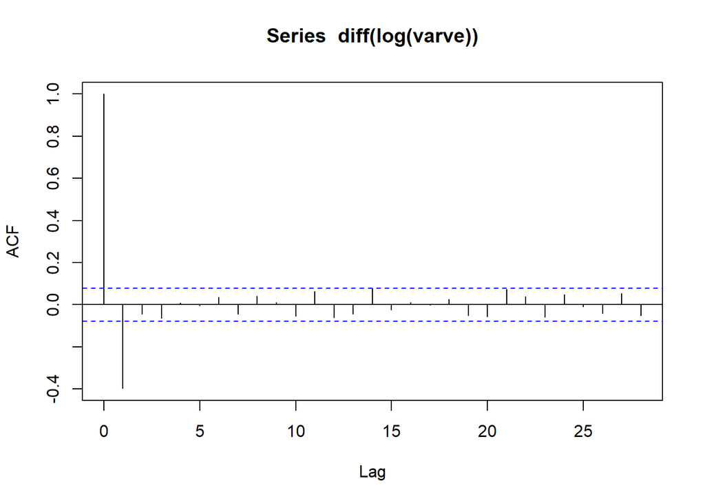

```r
acf(diff(log(varve))) # for part (d)
```

La gráfica de $u_t$ y su ACF parecen indicar estacionariedad. El ACF tiene un valor significativo en el desfase 1 (con un valor de −0,3974). Porque $u_t$ se puede escribir en la forma

$$u_t = log \Big
(\dfrac{x_t}{x_{t-1}}\Big) = log \Big ( 1 + \dfrac{x_t -
x_{t-1}}{x_{t-1}}\Big) \approx \dfrac{x_t -x_{t-1}}{x_{t-1}},$$
se puede interpretar como la proporción del cambio anual.

5. Con base en la muestra ACF de la serie transformada diferenciada calculada en (c), argumente que una generalización del modelo dado por el Ejemplo 1.23 podría ser razonable. Suponga que $u_t = \mu + w_t − \theta w_{t−1}$ es estacionario cuando las entradas $w_t$ se suponen independientes con media 0 y varianza $\sigma ^2 _w w$. Muestra que

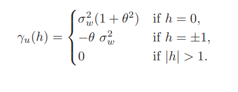

6. Con base en el inciso (e), use $\hat{\rho} _u(1)$ y la estimación de la varianza de $u_t, \hat{\gamma} _u(0)$, para derivar estimaciones de $\theta$ y $\sigma ^2 _w$. Esta es una aplicación del método de los momentos de la estadística clásica, donde los estimadores de los parámetros se derivan al equiparar los momentos de la muestra con los momentos teóricos.

2.10 Considere las dos series de tiempo semanales de petróleo y gas. La serie del petróleo está en dólares por barril, mientras que la serie del gas está en centavos por galón.

1. Trace los datos en el mismo gráfico. ¿A cuál de las series simuladas mostradas en la Sección 1.2 se parecen más estas series? ¿Crees que las series son estacionarias (explica tu respuesta)?

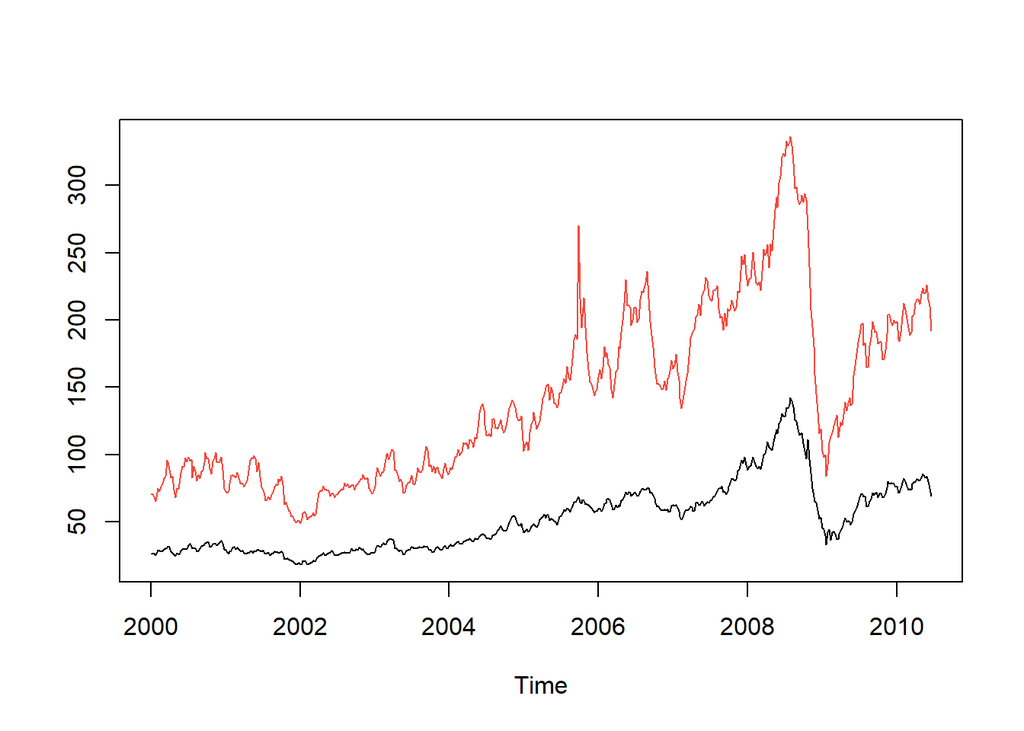

```r
ts.plot(oil, gas, col=1:2)
```

trazará los datos en el mismo gráfico. Los datos se parecen a los paseos aleatorios que se muestran en la figura 1.10. Mostramos en el Capítulo 1, Ejemplo 1.18, que las caminatas aleatorias no son estacionarias [esto también se trata en el Problema 1.8]. Consulte la Figura 2.2. Use la siguiente URL para obtener más detalles sobre el conjunto de datos o más series simultáneas: http://tonto.eia.doe.gov/dnav/pet/pet_pri_spt_s1_w.htm.

2. En economía, a menudo es el cambio porcentual en el precio (denominado tasa de crecimiento o rendimiento), más que el cambio absoluto del precio, lo que es importante. Argumente que se podría aplicar una transformación de la forma yt = ∇ log xt a los datos, donde xt es la serie de precios del petróleo o del gas. Sugerencia: recuerde la nota al pie 1.2.

Ver la respuesta a 2.8(d)

3. Transforme los datos como se describe en la parte (b), trace los datos en el mismo gráfico, mire los ACF de muestra de los datos transformados y comente.

El código está debajo y sigue las sugerencias. Las series transformadas parecen estacionarias y queda muy poca autocorrelación después de la transformación, por lo que una caminata aleatoria parece plausible para cada serie. Hay algunos valores muy extremos [se indica a los estudiantes que noten los valores atípicos en la parte (e)]. Las dos series parecen estar moviéndose al mismo tiempo [esto se enfatiza en las partes (d) y (e)].

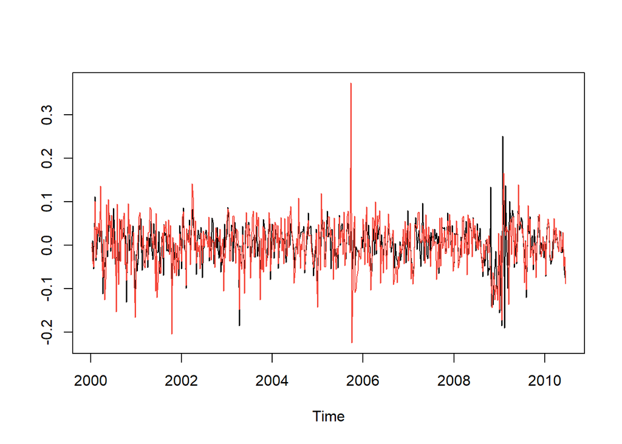

```r
poil = diff(log(oil))
pgas = diff(log(gas))
ts.plot(poil, pgas, col=1:2)
```

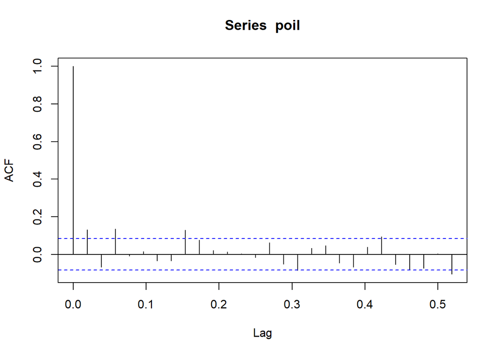

```r
acf(poil)
```

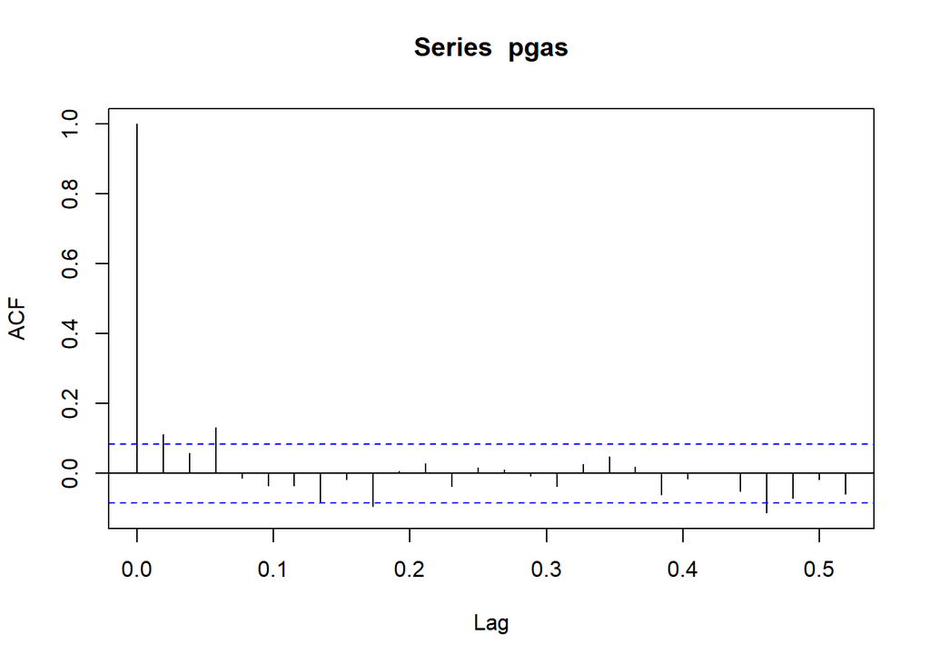

```r
acf(pgas)
```

5. Mostrar diagramas de dispersión de las series de tasas de crecimiento del petróleo y el gas para hasta tres semanas de anticipación de los precios del petróleo; incluya un suavizador no paramétrico en cada gráfico y comente los resultados (p. ej., ¿hay valores atípicos? ¿Las relaciones son lineales?).

6. Ha habido una serie de estudios que cuestionan si los precios de la gasolina responden más rápidamente cuando los precios del petróleo están subiendo que cuando los precios del petróleo están cayendo (“asimetría”). Intentaremos explorar esta cuestión aquí con una regresión retardada simple; ignoraremos algunos problemas obvios, como valores atípicos y errores autocorrelacionados, por lo que este no será un análisis definitivo. Sean Gt y Ot el gas y el petróleo las tasas de crecimiento.
7. Ajuste la regresión (y comente los resultados)

$$G_t = \alpha _1 + \alpha _2 I_t + \beta
_2 O_{t-1} + w_t$$

donde $I_t = 1$ si $O_t \geq 0$ y 0 en caso contrario (Es el indicador de crecimiento nulo o crecimiento positivo del precio del petróleo).

Hint:
$$poil = diff(log(oil))$$

$$pgas = diff(log(gas))$$

$$indi = ifelse(poil < 0, 0,
1)$$

$$mess = ts.intersect(pgas, poil, poilL =
lag(poil,-1), indi)$$

$$summary(fit <- lm(pgas~ poil + poilL
+ indi, data=mess))$$

2. ¿Cuál es el modelo ajustado cuando hay un crecimiento negativo en el precio del petróleo en el tiempo t? ¿Cuál es el modelo ajustado cuando no hay crecimiento o hay un crecimiento positivo en el precio del petróleo? ¿Estos resultados apoyan la hipótesis de la asimetría?

3. Analizar los residuos del ajuste y comentar.

```r
#plot.ts(resid(fit))
#acf(resid(fit))
```

Ejercicio Capitulos 3

3.22 Genere n = 50 observaciones a partir de un modelo gaussiano AR(1) con $phi = 0,99$ y $\sigma _w = 1$. Usando una técnica de estimación de su elección, compare la distribución asintótica aproximada de su estimación (la que usaría para la inferencia) con la resultados de un experimento de arranque (use B = 200).

A continuación se muestra el código R para este ejemplo usando Yule-Walker. La distribución asintótica es normal con media .99 y error estándar $\sqrt{1 − 0.99^2 /50} \approx 0.02$. La distribución bootstrap debería ser muy diferente a la distribución asintótica. (Si los estudiantes usan MLE, puede haber problemas porque $\phi$ está muy cerca del límite. Puede alertar a los alumnos sobre este hecho o dejar que lo averigüen por sí mismos).

```
##    Min. 1st Qu.  Median    Mean 3rd Qu.    Max.
##  0.5384  0.8065  0.8599  0.8444  0.8995  0.9538
```

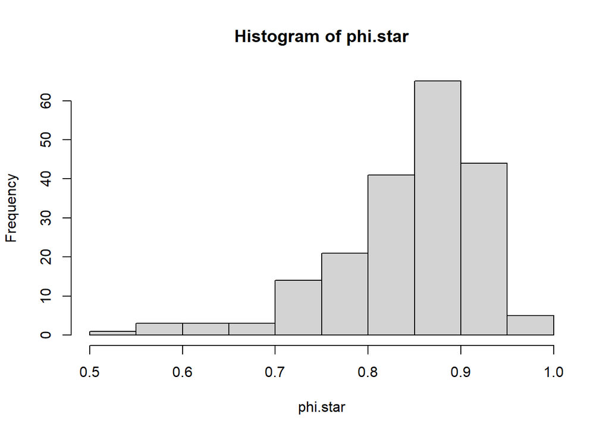

```
##
##   The decimal point is 2 digit(s) to the left of the |
##
##   52 | 8
##   54 |
##   56 | 7
##   58 | 64
##   60 |
##   62 | 341
##   64 | 1
##   66 |
##   68 | 12
##   70 | 05663
##   72 | 0079
##   74 | 669991347
##   76 | 30123
##   78 | 005790133459
##   80 | 01116789233689
##   82 | 033478134566689
##   84 | 0011222367781234445556669
##   86 | 00233445566667999112455578
##   88 | 1336666777890124456778889
##   90 | 0234444900122447779
##   92 | 1145566888912344456679
##   94 | 030022234
```

```r
x = arima.sim(list(ar=.99), n=50)
fit = ar.yw(x, order=1)
phi = fit$ar # estimate of phi
nboot = 200 # number of bootstrap replicates
resids = fit$resid[-1] # the first resid is NA
x.star = x # x[1] stays the same throughout
phi.star = rep(NA, nboot)
for (i in 1:nboot) {
resid.star = sample(resids, replace=TRUE)
for (t in 1:49) x.star[t+1] = phi*x.star[t] + resid.star[t]
phi.star[i] = ar.yw(x.star, order=1)$ar
}
summary(phi.star); hist(phi.star); stem(phi.star)
```

3.34 Adaptar un modelo ARIMA(p, d, q) a la serie anhídrido sulfuroso, so2, realizando todos los diagnósticos necesarios. Después de decidirse por un modelo adecuado, pronostique los datos en el futuro con cuatro períodos de tiempo (alrededor de un mes) y calcule intervalos de predicción del 95 % para cada uno de los cuatro pronósticos. Comentario. (El dióxido de azufre es uno de los contaminantes monitoreados en el estudio de mortalidad descrito en el Ejemplo 2.2.)

Hay tendencia, por lo que consideramos la (primera) serie diferenciada, que parece estacionaria. La investigación de ACF y PACF de los diferenciados sugiere un modelo ARMA(0,1) o ARMA(1,1). Ajustar un ARIMA(0,1,1) y ARIMA(1,1,1) a los datos originales indica el modelo ARIMA(0,1,1); el parámetro AR no es significativo en el ajuste ARIMA(1,1,1). Los residuos parecen ser (en el límite) blancos, pero no normales; hay numerosos valores atípicos. Ajustar ARIMA(0,1,1) a log(so2) elimina los valores atípicos, pero no cambia nada más de forma notable

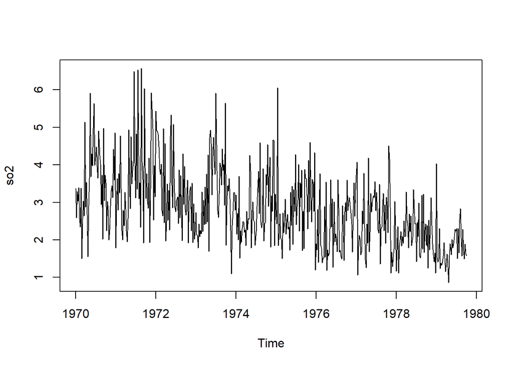

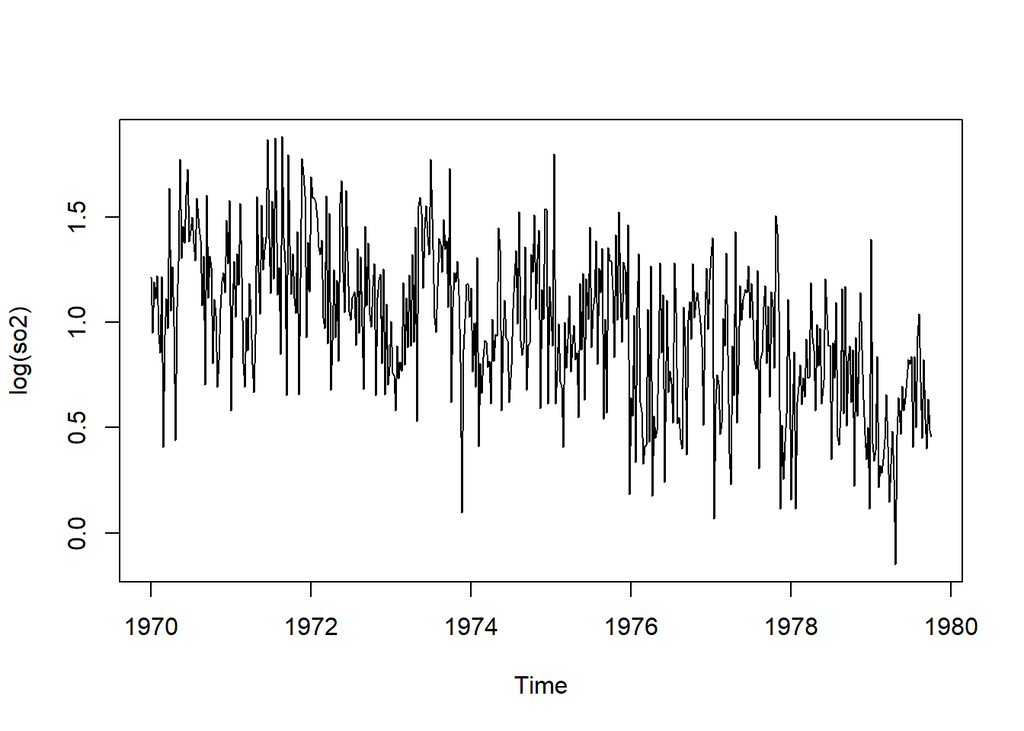

```r
plot(so2); plot(log(so2))
```

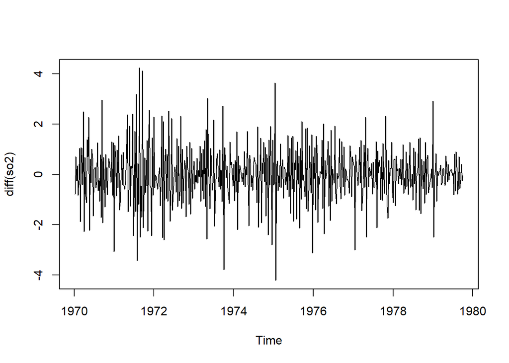

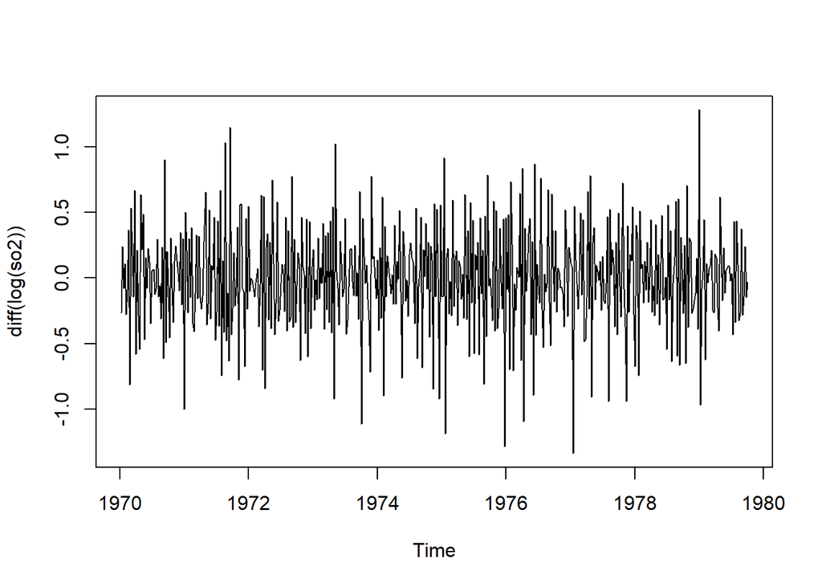

```r
plot(diff(so2)); plot(diff(log(so2)))
```

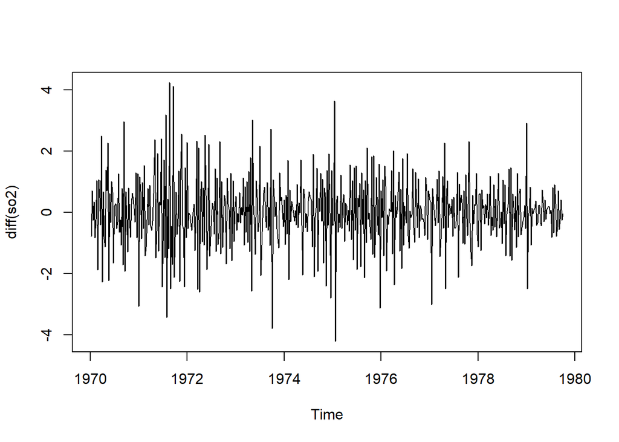

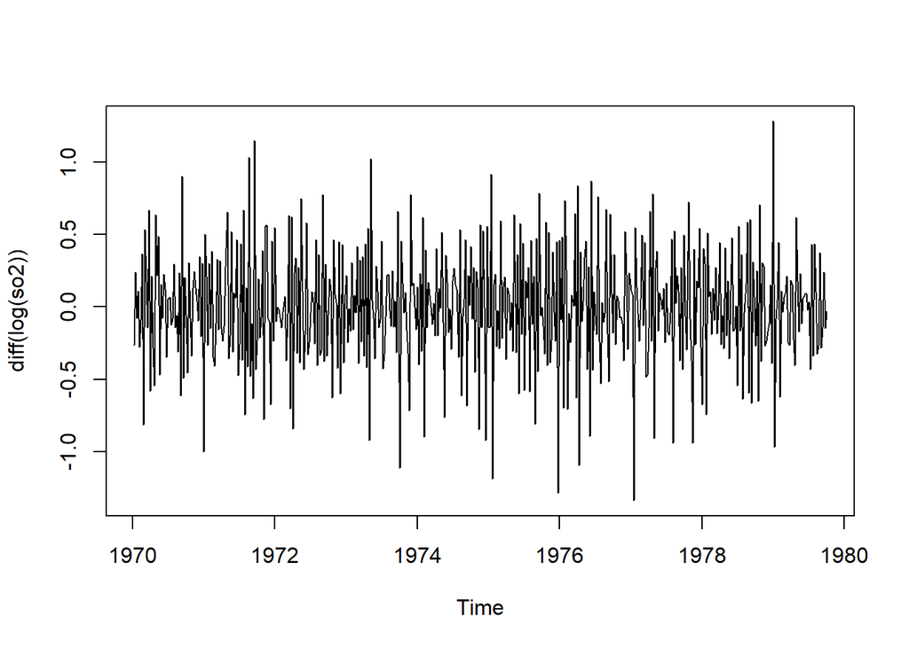

```r
plot(diff(so2)); plot(diff(log(so2)))
```

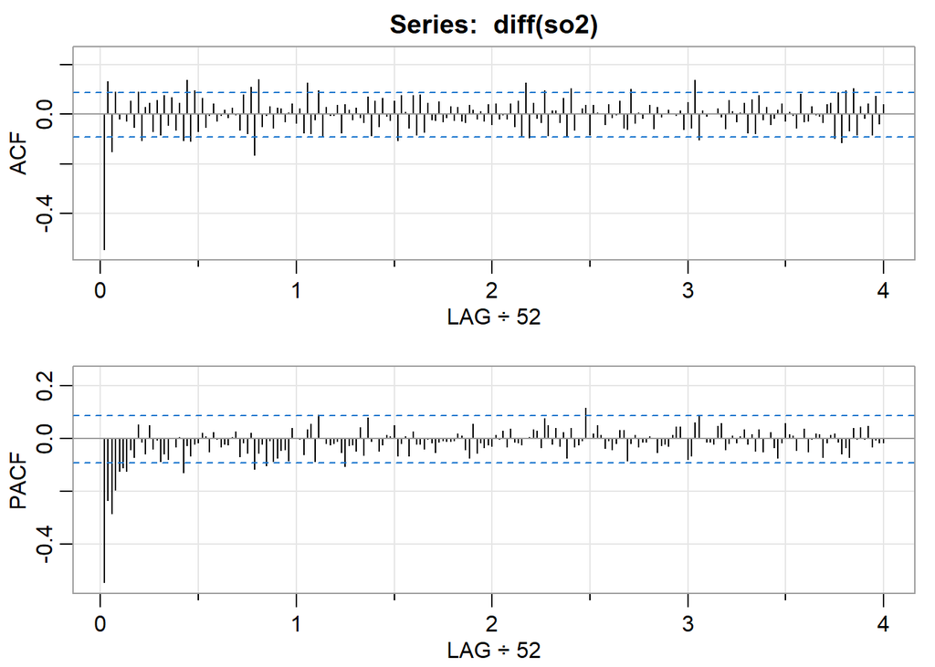

```
##       [,1]  [,2]  [,3]  [,4]  [,5]  [,6]  [,7]  [,8]  [,9] [,10] [,11] [,12]
## ACF  -0.54  0.13 -0.15  0.09 -0.02  0.00 -0.03  0.05 -0.05  0.09 -0.11  0.03
## PACF -0.54 -0.24 -0.28 -0.19 -0.12 -0.11 -0.12 -0.04 -0.07  0.05 -0.01 -0.06
##      [,13] [,14] [,15] [,16] [,17] [,18] [,19] [,20] [,21] [,22] [,23] [,24]
## ACF   0.05 -0.07  0.06 -0.08  0.08 -0.05  0.07 -0.06  0.04 -0.11  0.14 -0.11
## PACF  0.05 -0.04 -0.01 -0.09 -0.06 -0.08  0.00 -0.03  0.01 -0.13 -0.03 -0.06
##      [,25] [,26] [,27] [,28] [,29] [,30] [,31] [,32] [,33] [,34] [,35] [,36]
## ACF   0.10 -0.07  0.06 -0.05 -0.01  0.04 -0.03 -0.01  0.02 -0.01  0.03  0.00
## PACF -0.02 -0.01  0.02  0.01 -0.05  0.02  0.00 -0.03 -0.02 -0.02  0.01  0.03
##      [,37] [,38] [,39] [,40] [,41] [,42] [,43] [,44] [,45] [,46] [,47] [,48]
## ACF  -0.06  0.08 -0.08  0.11 -0.17  0.14 -0.05 -0.01  0.03 -0.06  0.03  0.02
## PACF -0.07 -0.02 -0.06  0.02 -0.11 -0.06 -0.02 -0.10 -0.01 -0.09 -0.07 -0.04
##      [,49] [,50] [,51] [,52] [,53] [,54] [,55] [,56] [,57] [,58] [,59] [,60]
## ACF  -0.03  0.01  0.04 -0.04  0.02 -0.07  0.13 -0.08 -0.02  0.10 -0.09  0.03
## PACF -0.04 -0.08  0.04  0.00  0.00 -0.06  0.04  0.06 -0.09  0.09  0.00 -0.02
##      [,61] [,62] [,63] [,64] [,65] [,66] [,67] [,68] [,69] [,70] [,71] [,72]
## ACF  -0.01 -0.01  0.04 -0.08  0.04  0.02 -0.02  0.03 -0.01 -0.03  0.07 -0.09
## PACF -0.02 -0.02 -0.01 -0.05 -0.10 -0.03 -0.02 -0.05  0.04 -0.06  0.08 -0.01
##      [,73] [,74] [,75] [,76] [,77] [,78] [,79] [,80] [,81] [,82] [,83] [,84]
## ACF   0.05 -0.05  0.06 -0.01 -0.02  0.05 -0.11  0.08  0.01 -0.06  0.08 -0.08
## PACF  0.00 -0.05 -0.02  0.01  0.01  0.05 -0.07 -0.02  0.01 -0.07  0.03 -0.02
##      [,85] [,86] [,87] [,88] [,89] [,90] [,91] [,92] [,93] [,94] [,95] [,96]
## ACF   0.08 -0.07  0.05 -0.02 -0.02  0.05 -0.03 -0.01  0.03 -0.02  0.03 -0.03
## PACF -0.02 -0.04  0.00 -0.02 -0.05 -0.01 -0.01 -0.01 -0.01 -0.01  0.02  0.01
##      [,97] [,98] [,99] [,100] [,101] [,102] [,103] [,104] [,105] [,106] [,107]
## ACF  -0.03  0.04  0.02  -0.02   0.01  -0.03   0.04  -0.04   0.04  -0.02   0.00
## PACF -0.04 -0.07  0.06  -0.06  -0.01  -0.03  -0.02  -0.03   0.01   0.00   0.03
##      [,108] [,109] [,110] [,111] [,112] [,113] [,114] [,115] [,116] [,117]
## ACF   -0.02   0.04  -0.05   0.05  -0.09   0.13  -0.09   0.05  -0.02  -0.03
## PACF  -0.03   0.04  -0.01  -0.02  -0.02   0.00   0.00   0.04   0.03  -0.03
##      [,118] [,119] [,120] [,121] [,122] [,123] [,124] [,125] [,126] [,127]
## ACF    0.10  -0.09   0.01   0.01  -0.03   0.06  -0.09   0.10  -0.06   0.00
## PACF   0.08   0.05  -0.02   0.04  -0.03   0.02  -0.07   0.04  -0.03  -0.02
##      [,128] [,129] [,130] [,131] [,132] [,133] [,134] [,135] [,136] [,137]
## ACF    0.02   0.04  -0.08   0.04   0.01   0.00  -0.04   0.04  -0.01   0.00
## PACF  -0.01   0.12   0.00   0.02   0.05   0.01  -0.04  -0.01  -0.04  -0.02
##      [,138] [,139] [,140] [,141] [,142] [,143] [,144] [,145] [,146] [,147]
## ACF    0.06  -0.06  -0.06   0.10  -0.04   0.01  -0.02   0.00   0.04  -0.06
## PACF   0.03   0.03  -0.08  -0.02   0.01  -0.03  -0.01  -0.01   0.01   0.00
##      [,148] [,149] [,150] [,151] [,152] [,153] [,154] [,155] [,156] [,157]
## ACF    0.03  -0.01   0.00   0.02   0.00   0.00   0.02  -0.06   0.05  -0.06
## PACF  -0.05  -0.03  -0.02  -0.03   0.01   0.04   0.05   0.00  -0.08  -0.07
##      [,158] [,159] [,160] [,161] [,162] [,163] [,164] [,165] [,166] [,167]
## ACF    0.14  -0.10   0.01  -0.01   0.00   0.00   0.02  -0.01  -0.06   0.06
## PACF   0.06   0.09   0.00  -0.01  -0.01  -0.02   0.05   0.06  -0.04  -0.02
##      [,168] [,169] [,170] [,171] [,172] [,173] [,174] [,175] [,176] [,177]
## ACF    0.01  -0.03   0.01   0.04  -0.08   0.06  -0.08   0.08  -0.02   0.03
## PACF   0.01  -0.01   0.01   0.03  -0.02   0.02  -0.05   0.04  -0.05   0.00
##      [,178] [,179] [,180] [,181] [,182] [,183] [,184] [,185] [,186] [,187]
## ACF   -0.04  -0.02   0.02   0.04  -0.03   0.01  -0.01  -0.06   0.08  -0.03
## PACF   0.02  -0.03  -0.07  -0.02   0.06   0.02   0.01  -0.04   0.00   0.04
##      [,188] [,189] [,190] [,191] [,192] [,193] [,194] [,195] [,196] [,197]
## ACF   -0.03   0.03   0.00  -0.01  -0.03   0.04   0.05  -0.10   0.09  -0.11
## PACF  -0.05   0.00   0.02   0.02  -0.07  -0.02   0.01   0.02  -0.01  -0.06
##      [,198] [,199] [,200] [,201] [,202] [,203] [,204] [,205] [,206] [,207]
## ACF    0.10  -0.07   0.10  -0.08   0.03  -0.02   0.04  -0.08   0.07  -0.04
## PACF  -0.03  -0.07   0.04   0.00   0.04   0.00   0.05  -0.03   0.00  -0.02
##      [,208]
## ACF    0.04
## PACF  -0.01
```

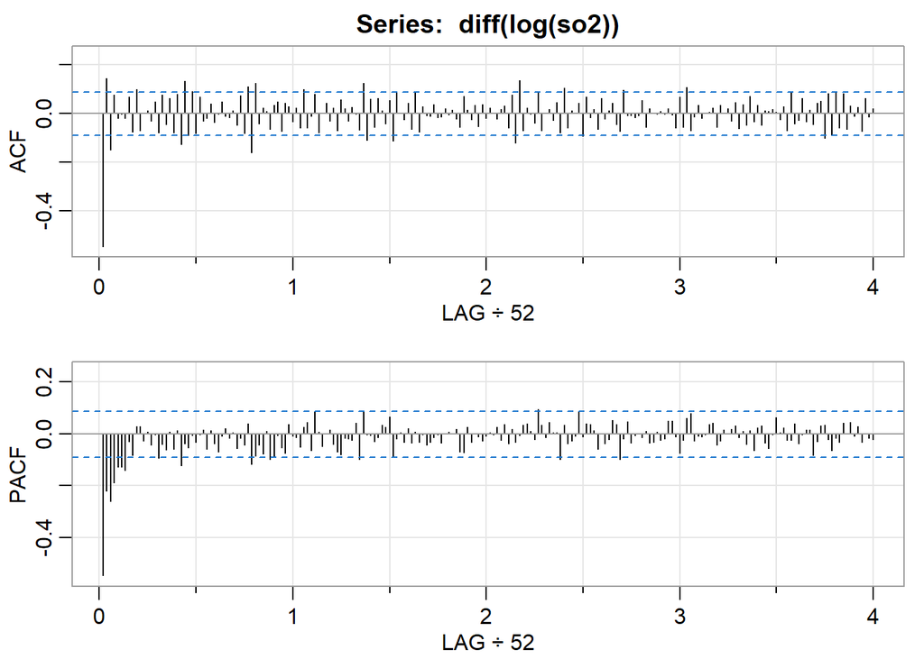

```
##       [,1]  [,2]  [,3]  [,4]  [,5]  [,6]  [,7]  [,8]  [,9] [,10] [,11] [,12]
## ACF  -0.55  0.14 -0.15  0.08 -0.02  0.00 -0.02  0.07 -0.08  0.10 -0.07  0.00
## PACF -0.55 -0.22 -0.26 -0.19 -0.13 -0.13 -0.14 -0.03 -0.08  0.03  0.03 -0.03
##      [,13] [,14] [,15] [,16] [,17] [,18] [,19] [,20] [,21] [,22] [,23] [,24]
## ACF   0.01 -0.03  0.05 -0.08  0.08 -0.05  0.06 -0.08  0.08 -0.13  0.13 -0.09
## PACF  0.01 -0.04  0.00 -0.09 -0.04 -0.06  0.01 -0.06  0.01 -0.12 -0.04 -0.05
##      [,25] [,26] [,27] [,28] [,29] [,30] [,31] [,32] [,33] [,34] [,35] [,36]
## ACF   0.09 -0.08  0.07 -0.03 -0.02  0.04 -0.04  0.00  0.05 -0.01 -0.02  0.01
## PACF -0.01 -0.03  0.00  0.02 -0.06  0.01 -0.04 -0.07 -0.01  0.02 -0.02  0.00
##      [,37] [,38] [,39] [,40] [,41] [,42] [,43] [,44] [,45] [,46] [,47] [,48]
## ACF  -0.05  0.07 -0.08  0.11 -0.16  0.12 -0.04  0.02  0.01 -0.06  0.03  0.05
## PACF -0.06 -0.02 -0.04  0.04 -0.12 -0.09 -0.04 -0.08  0.01 -0.10 -0.09 -0.01
##      [,49] [,50] [,51] [,52] [,53] [,54] [,55] [,56] [,57] [,58] [,59] [,60]
## ACF  -0.07  0.04  0.03 -0.03  0.02 -0.06  0.10 -0.06 -0.01  0.08 -0.08  0.00
## PACF -0.05 -0.08  0.04 -0.01 -0.01 -0.05  0.03  0.04 -0.07  0.08  0.01 -0.05
##      [,61] [,62] [,63] [,64] [,65] [,66] [,67] [,68] [,69] [,70] [,71] [,72]
## ACF   0.04 -0.03  0.02 -0.07  0.06  0.02 -0.03  0.02  0.00 -0.07  0.12 -0.11
## PACF  0.00  0.01 -0.04 -0.07 -0.08 -0.02 -0.02 -0.02  0.04 -0.10  0.09  0.00
##      [,73] [,74] [,75] [,76] [,77] [,78] [,79] [,80] [,81] [,82] [,83] [,84]
## ACF   0.06 -0.06  0.06  0.01 -0.04  0.05 -0.11  0.09     0 -0.03  0.04 -0.07
## PACF -0.01 -0.03 -0.01  0.03  0.03  0.07 -0.09 -0.02     0 -0.03  0.02 -0.03
##      [,85] [,86] [,87] [,88] [,89] [,90] [,91] [,92] [,93] [,94] [,95] [,96]
## ACF   0.08 -0.08  0.03 -0.01 -0.01  0.03 -0.02 -0.01  0.02 -0.01  0.01 -0.02
## PACF  0.01 -0.03  0.00 -0.04 -0.03 -0.01  0.00 -0.03  0.00  0.01  0.00  0.02
##      [,97] [,98] [,99] [,100] [,101] [,102] [,103] [,104] [,105] [,106] [,107]
## ACF  -0.06  0.07  0.02  -0.02   0.03  -0.05   0.04  -0.02   0.02      0  -0.02
## PACF -0.07 -0.07  0.03  -0.03   0.00  -0.01  -0.03  -0.01   0.00      0   0.03
##      [,108] [,109] [,110] [,111] [,112] [,113] [,114] [,115] [,116] [,117]
## ACF    0.02   0.03  -0.06   0.07  -0.12   0.13  -0.07   0.02   0.00  -0.04
## PACF  -0.03   0.04  -0.04   0.02  -0.03  -0.01   0.03   0.04   0.01  -0.02
##      [,118] [,119] [,120] [,121] [,122] [,123] [,124] [,125] [,126] [,127]
## ACF    0.09  -0.07   0.00   0.02  -0.03   0.05  -0.08   0.10  -0.06   0.01
## PACF   0.10   0.03  -0.02   0.04   0.01   0.00  -0.10   0.03  -0.04  -0.03
##      [,128] [,129] [,130] [,131] [,132] [,133] [,134] [,135] [,136] [,137]
## ACF    0.00   0.04  -0.09   0.07  -0.02   0.02  -0.07   0.06  -0.02   0.01
## PACF  -0.01   0.09  -0.01   0.04   0.04   0.01  -0.06   0.00  -0.04  -0.02
##      [,138] [,139] [,140] [,141] [,142] [,143] [,144] [,145] [,146] [,147]
## ACF    0.04  -0.04  -0.07   0.09  -0.01  -0.01  -0.02  -0.01   0.05  -0.06
## PACF   0.05   0.04  -0.10  -0.02   0.05  -0.03  -0.01   0.00  -0.01   0.01
##      [,148] [,149] [,150] [,151] [,152] [,153] [,154] [,155] [,156] [,157]
## ACF    0.02   0.00   0.00   0.01   0.00   0.02  -0.01  -0.06   0.07  -0.06
## PACF  -0.03  -0.03   0.01  -0.03  -0.02   0.05   0.05  -0.01  -0.07  -0.02
##      [,158] [,159] [,160] [,161] [,162] [,163] [,164] [,165] [,166] [,167]
## ACF    0.11  -0.07  -0.01   0.03  -0.02      0   0.01   0.02  -0.06   0.03
## PACF   0.06   0.08  -0.03  -0.01  -0.01      0   0.04   0.04  -0.04  -0.03
##      [,168] [,169] [,170] [,171] [,172] [,173] [,174] [,175] [,176] [,177]
## ACF    0.00   0.02  -0.03   0.04  -0.06   0.04  -0.05   0.07  -0.03   0.03
## PACF   0.02   0.00   0.02   0.03  -0.01   0.01  -0.04   0.01  -0.06   0.02
##      [,178] [,179] [,180] [,181] [,182] [,183] [,184] [,185] [,186] [,187]
## ACF   -0.05   0.01   0.01   0.02   0.01  -0.02   0.03  -0.07   0.09  -0.04
## PACF   0.03  -0.03  -0.06   0.00   0.06   0.01   0.02  -0.02  -0.03   0.04
##      [,188] [,189] [,190] [,191] [,192] [,193] [,194] [,195] [,196] [,197]
## ACF   -0.03   0.06  -0.03   0.01  -0.04   0.04   0.05  -0.10   0.08  -0.09
## PACF  -0.04   0.00   0.01   0.02  -0.08  -0.03   0.03   0.03  -0.02  -0.06
##      [,198] [,199] [,200] [,201] [,202] [,203] [,204] [,205] [,206] [,207]
## ACF    0.08  -0.06   0.08  -0.07   0.03  -0.01   0.02  -0.07   0.06  -0.01
## PACF  -0.02  -0.03   0.04   0.00   0.05  -0.01   0.03  -0.03   0.00  -0.02
##      [,208]
## ACF    0.02
## PACF  -0.02
```

```r
acf2(diff(so2)); acf2(diff(log(so2)))
```

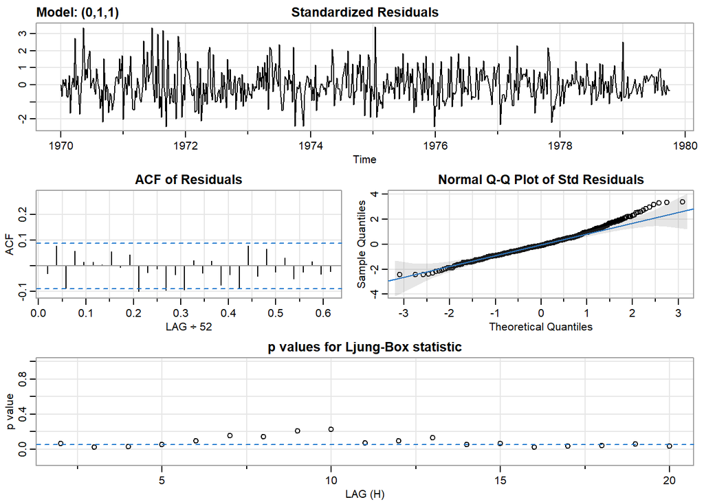

```
## $fit
##
## Call:
## arima(x = xdata, order = c(p, d, q), seasonal = list(order = c(P, D, Q), period = S),
##     xreg = constant, transform.pars = trans, fixed = fixed, optim.control = list(trace = trc,
##         REPORT = 1, reltol = tol))
##
## Coefficients:
##           ma1  constant
##       -0.8403   -0.0024
## s.e.   0.0275    0.0063
##
## sigma^2 estimated as 0.7846:  log likelihood = -658.53,  aic = 1323.07
##
## $degrees_of_freedom
## [1] 505
##
## $ttable
##          Estimate     SE  t.value p.value
## ma1       -0.8403 0.0275 -30.5410  0.0000
## constant  -0.0024 0.0063  -0.3801  0.7041
##
## $AIC
## [1] 2.609604
##
## $AICc
## [1] 2.609651
##
## $BIC
## [1] 2.634625
```

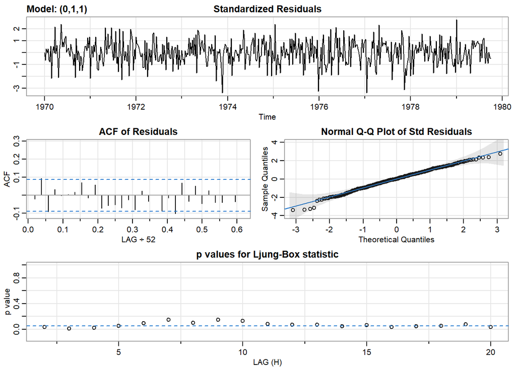

```
## $fit
##
## Call:
## arima(x = xdata, order = c(p, d, q), seasonal = list(order = c(P, D, Q), period = S),
##     xreg = constant, transform.pars = trans, fixed = fixed, optim.control = list(trace = trc,
##         REPORT = 1, reltol = tol))
##
## Coefficients:
##           ma1  constant
##       -0.8374   -0.0010
## s.e.   0.0284    0.0022
##
## sigma^2 estimated as 0.09507:  log likelihood = -123.48,  aic = 252.96
##
## $degrees_of_freedom
## [1] 505
##
## $ttable
##          Estimate     SE  t.value p.value
## ma1       -0.8374 0.0284 -29.5141  0.0000
## constant  -0.0010 0.0022  -0.4450  0.6565
##
## $AIC
## [1] 0.4989322
##
## $AICc
## [1] 0.4989792
##
## $BIC
## [1] 0.523953
```

```r
sarima(so2,0,1,1); sarima(log(so2),0,1,1)
```

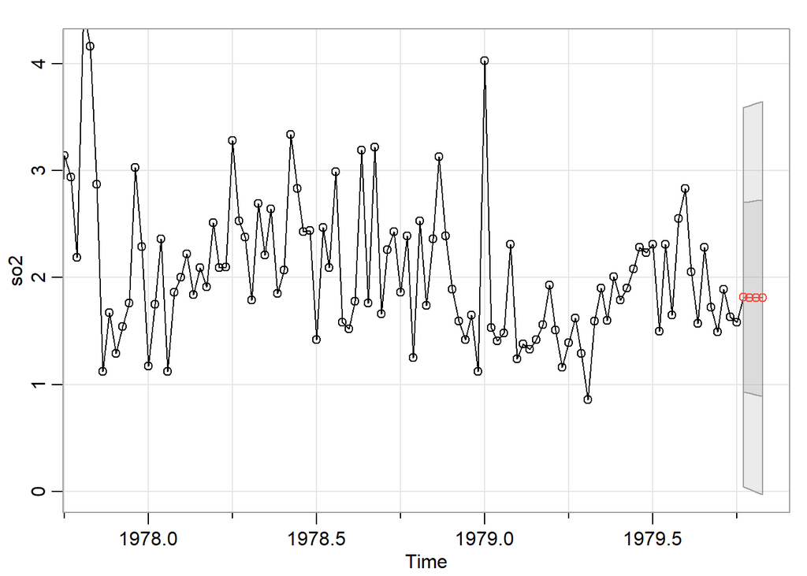

```
## $pred
## Time Series:
## Start = c(1979, 41)
## End = c(1979, 44)
## Frequency = 52
## [1] 1.816620 1.814207 1.811795 1.809382
##
## $se
## Time Series:
## Start = c(1979, 41)
## End = c(1979, 44)
## Frequency = 52
## [1] 0.8858024 0.8970246 0.9081081 0.9190579
```

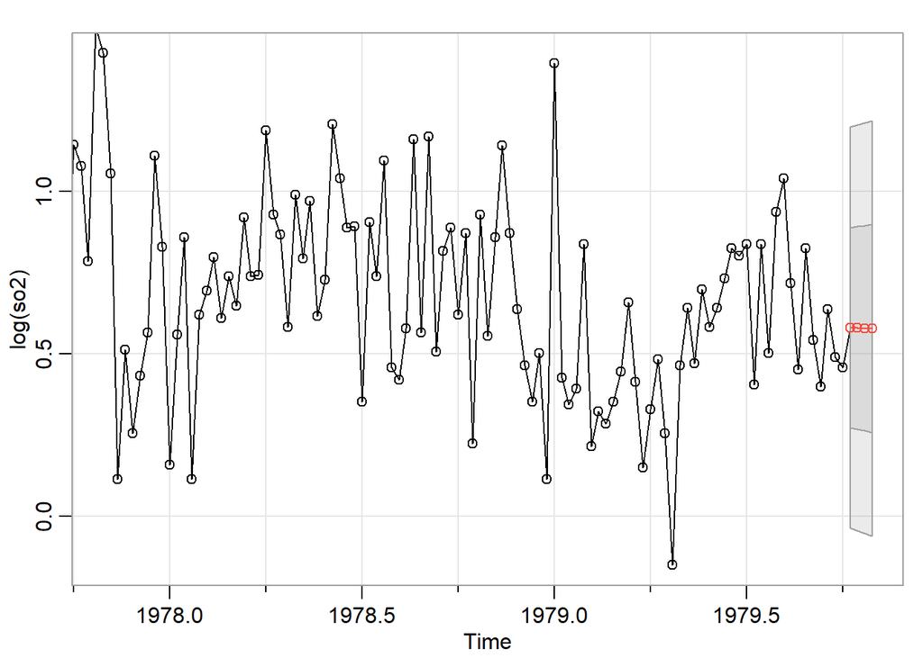

```
## $pred
## Time Series:
## Start = c(1979, 41)
## End = c(1979, 44)
## Frequency = 52
## [1] 0.5806426 0.5796415 0.5786405 0.5776394
##
## $se
## Time Series:
## Start = c(1979, 41)
## End = c(1979, 44)
## Frequency = 52
## [1] 0.3083310 0.3123783 0.3163737 0.3203193
```

```r
sarima.for(so2,4,0,1,1); sarima.for(log(so2),4,0,1,1)
```

3.35 Sea St los datos de ventas mensuales en ventas (n = 150), y sea Lt el indicador líder en adelanto.

1. Ajuste un modelo ARIMA a St , los datos de ventas mensuales. Analice el ajuste de su modelo paso a paso, presentando su (A) examen inicial de los datos, (B) transformaciones, si es necesario, (C) identificación inicial de los órdenes de dependencia y el grado de diferenciación, (D) parámetro estimación, (E) diagnóstico residual y elección del modelo.

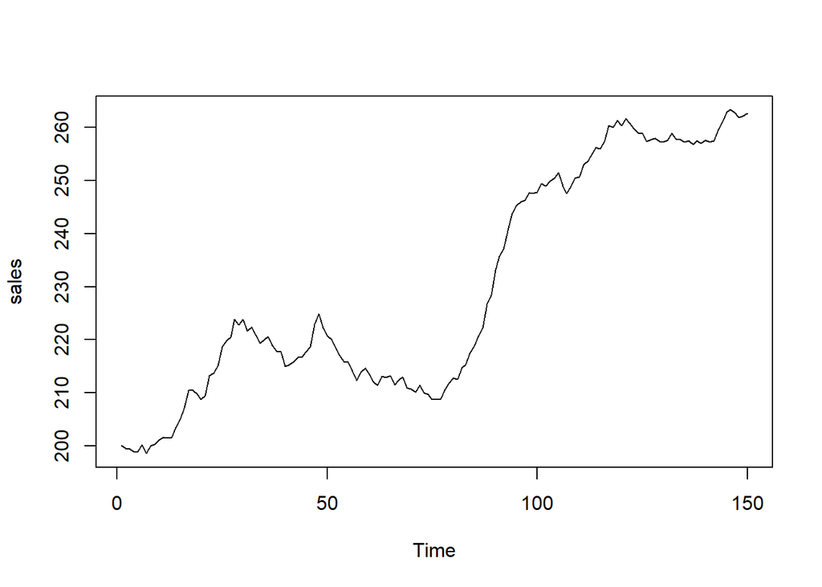

```r
plot(sales)
```

parece una caminata aleatoria, por lo que la diferencia d = 1, (puede hacer esto con log(sales) pero no es necesario).

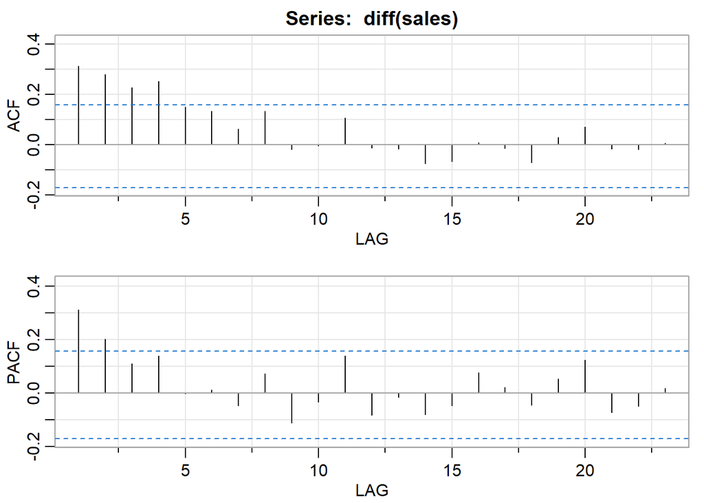

```
##      [,1] [,2] [,3] [,4] [,5] [,6]  [,7] [,8]  [,9] [,10] [,11] [,12] [,13]
## ACF  0.31 0.28 0.23 0.25 0.15 0.13  0.06 0.13 -0.02  0.00  0.11 -0.01 -0.02
## PACF 0.31 0.20 0.11 0.14 0.00 0.01 -0.05 0.07 -0.11 -0.03  0.14 -0.08 -0.02
##      [,14] [,15] [,16] [,17] [,18] [,19] [,20] [,21] [,22] [,23]
## ACF  -0.07 -0.07  0.01 -0.02 -0.07  0.03  0.07 -0.02 -0.02  0.01
## PACF -0.08 -0.05  0.08  0.02 -0.04  0.05  0.12 -0.07 -0.05  0.02
```

```r
acf2(diff(sales))
```

Tanto ACF como PACF siguen, así que elija p = q = 1

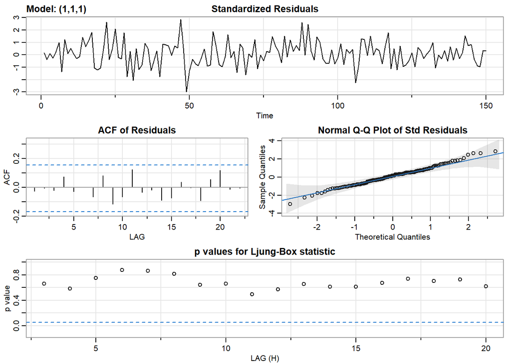

```
## $fit
##
## Call:
## arima(x = xdata, order = c(p, d, q), seasonal = list(order = c(P, D, Q), period = S),
##     include.mean = !no.constant, transform.pars = trans, fixed = fixed, optim.control = list(trace = trc,
##         REPORT = 1, reltol = tol))
##
## Coefficients:
##          ar1      ma1
##       0.8800  -0.6415
## s.e.  0.0644   0.1035
##
## sigma^2 estimated as 1.775:  log likelihood = -254.37,  aic = 514.74
##
## $degrees_of_freedom
## [1] 147
##
## $ttable
##     Estimate     SE t.value p.value
## ar1   0.8800 0.0644 13.6628       0
## ma1  -0.6415 0.1035 -6.1968       0
##
## $AIC
## [1] 3.454604
##
## $AICc
## [1] 3.455156
##
## $BIC
## [1] 3.515086
```

```r
sarima(sales,1,1,1, no.constant=TRUE)
```

Note que encaja bien

2. Use el CCF y las gráficas de retardo entre $\triangledown S_t$ y $ L_t$ argumentar que una regresión de $\triangledown S_t$ en $\triangledown L_{t-3}$$ es razonable. [Tenga en cuenta que en lag2.plot(), la primera serie nombrada es la que se retrasa.]

```r
#ccf(diff(sales),diff(lead))
```

```r
#lag2.plot(diff(lead), diff(sales),8)
```

```r
lag2.plot
```

[output not shown]

3. Ajuste el modelo de regresión $\triangledown S_t= \beta _0 + \beta _1 \triangledown L_{t−3} + x_t$, donde $x_t$ es un proceso ARMA (explique cómo decidió su modelo para $x_t$). Discuta sus resultados. [Consulte el Ejemplo 3.45 para obtener ayuda sobre la codificación de este problema.]

```r
#u = ts.intersect(diff(sales), lag(diff(lead),-3))
#ds = u[,1]
#dl3 = u[,2]
#(fit1 = lm(ds~dl3)) # beta1hat is highly significant
#acf2(resid(fit1)) # => an AR(1) for the residuals
#(fit2 = sarima(ds, 1,0,0, xreg=dl3)) # reg with ar1 errors
#plot(resid(fit2$fit))
#acf2(resid(fit2$fit))
```

3.42 Ajuste un modelo ARIMA estacional de su elección a los datos de desempleo en UnempRate. Utilice el modelo estimado para pronosticar los próximos 12 meses.

Este conjunto de datos es una actualización de unemp, pero en términos de porcentaje de desempleados. Las técnicas son las mismas que en el problema anterior y el modelo es casi el mismo; se necesita un parámetro MA adicional

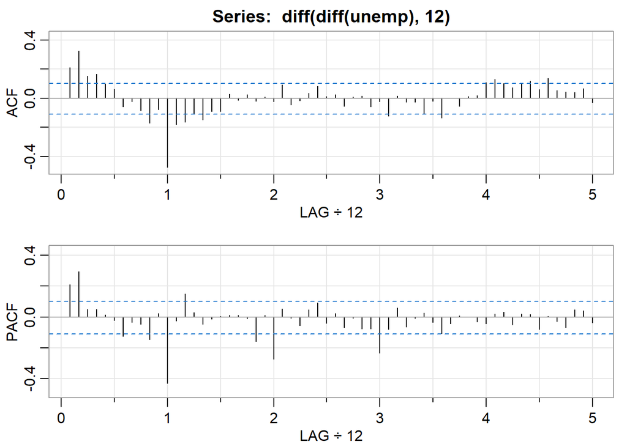

```
##      [,1] [,2] [,3] [,4] [,5]  [,6]  [,7]  [,8]  [,9] [,10] [,11] [,12] [,13]
## ACF  0.21 0.33 0.15 0.17 0.10  0.06 -0.06 -0.02 -0.09 -0.17 -0.08 -0.48 -0.18
## PACF 0.21 0.29 0.05 0.05 0.01 -0.02 -0.12 -0.03 -0.05 -0.15  0.02 -0.43 -0.02
##      [,14] [,15] [,16] [,17] [,18] [,19] [,20] [,21] [,22] [,23] [,24] [,25]
## ACF  -0.16 -0.11 -0.15 -0.09 -0.09  0.03 -0.01  0.02 -0.02  0.01 -0.02  0.09
## PACF  0.15  0.03 -0.04 -0.01  0.00  0.01  0.01 -0.01 -0.16  0.01 -0.27  0.05
##      [,26] [,27] [,28] [,29] [,30] [,31] [,32] [,33] [,34] [,35] [,36] [,37]
## ACF  -0.05 -0.01  0.03  0.08  0.01  0.03 -0.05  0.01  0.02 -0.06 -0.02 -0.12
## PACF -0.01 -0.05  0.05  0.09 -0.04  0.02 -0.07 -0.01 -0.08 -0.08 -0.23 -0.08
##      [,38] [,39] [,40] [,41] [,42] [,43] [,44] [,45] [,46] [,47] [,48] [,49]
## ACF   0.01 -0.03 -0.03 -0.10 -0.02 -0.13  0.00 -0.06  0.01  0.02  0.11  0.13
## PACF  0.06 -0.07 -0.01  0.03 -0.03 -0.11 -0.04  0.01  0.00 -0.03 -0.04  0.02
##      [,50] [,51] [,52] [,53] [,54] [,55] [,56] [,57] [,58] [,59] [,60]
## ACF   0.10  0.07  0.10  0.12  0.06  0.14  0.05  0.04  0.04  0.07 -0.03
## PACF  0.03 -0.05  0.02  0.02 -0.08  0.00 -0.03 -0.07  0.05  0.04 -0.04
```

```r
acf2(diff(diff(unemp),12), 60)
```

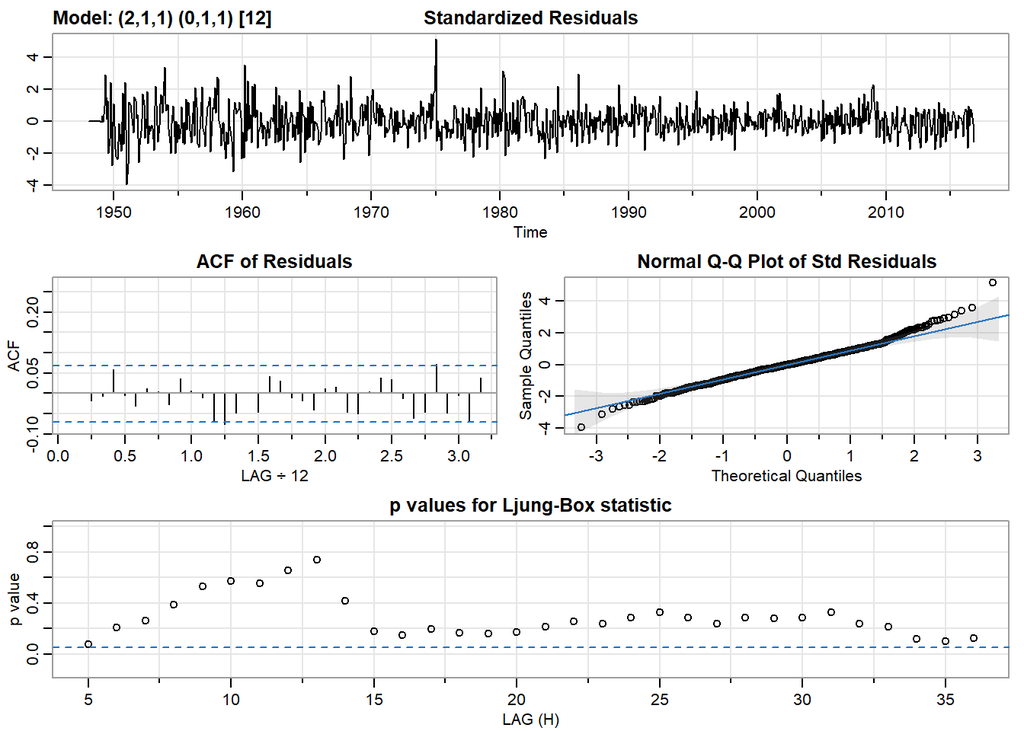

```
## $fit
##
## Call:
## arima(x = xdata, order = c(p, d, q), seasonal = list(order = c(P, D, Q), period = S),
##     include.mean = !no.constant, transform.pars = trans, fixed = fixed, optim.control = list(trace = trc,
##         REPORT = 1, reltol = tol))
##
## Coefficients:
##          ar1     ar2      ma1     sma1
##       0.5897  0.1342  -0.4831  -0.7676
## s.e.  0.1105  0.0465   0.1090   0.0254
##
## sigma^2 estimated as 0.05559:  log likelihood = 15.69,  aic = -21.38
##
## $degrees_of_freedom
## [1] 810
##
## $ttable
##      Estimate     SE  t.value p.value
## ar1    0.5897 0.1105   5.3353   0.000
## ar2    0.1342 0.0465   2.8826   0.004
## ma1   -0.4831 0.1090  -4.4323   0.000
## sma1  -0.7676 0.0254 -30.2459   0.000
##
## $AIC
## [1] -0.02626168
##
## $AICc
## [1] -0.02620094
##
## $BIC
## [1] 0.002620143
```

```r
sarima(UnempRate, 2, 1, 1, 0, 1, 1, 12)
```

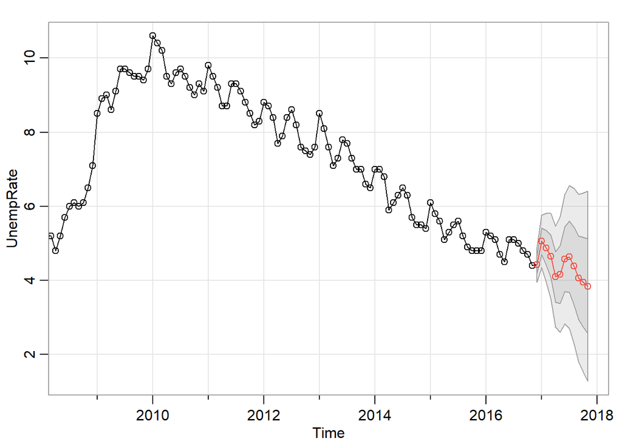

```
## $pred
##           Jan      Feb      Mar      Apr      May      Jun      Jul      Aug
## 2016
## 2017 5.052758 4.877218 4.649057 4.095737 4.154975 4.570231 4.632799 4.383510
##           Sep      Oct      Nov      Dec
## 2016                            4.421514
## 2017 4.062609 3.944758 3.838447
##
## $se
##            Jan       Feb       Mar       Apr       May       Jun       Jul
## 2016
## 2017 0.3516689 0.4670626 0.5766148 0.6811037 0.7804349 0.8747939 0.9644385
##            Aug       Sep       Oct       Nov       Dec
## 2016                                         0.2357858
## 2017 1.0496799 1.1308479 1.2082705 1.2822619
```

```r
sarima.for(UnempRate, 12, 2, 1, 1, 0, 1, 1, 12)
```

EJERCICIOS CAPITULO 4

4.10 Los niveles de concentración de sal que se sabe que ocurrieron sobre las filas, correspondientes a los niveles de temperatura promedio para los datos de la ciencia del suelo considerados en la Figura 1.18 y la Figura 1.19, están en salt y saltemp . Trace la serie y luego identifique las frecuencias dominantes realizando análisis espectrales separados en las dos series. Incluya intervalos de confianza para las frecuencias dominantes e interprete sus hallazgos

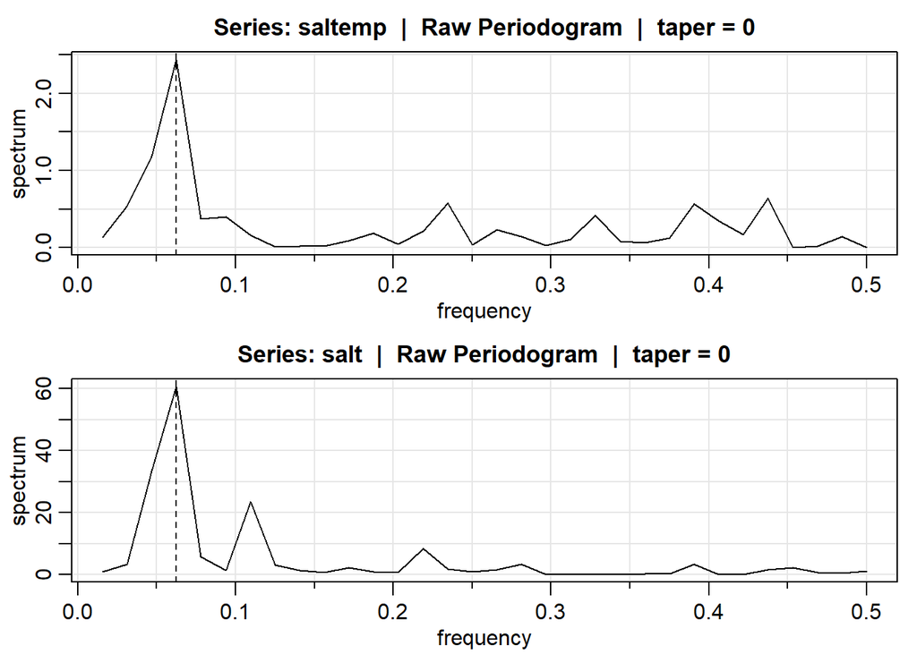

```r
par(mfrow=c(2,1)) # for CIs, remove log="no" below
mvspec(saltemp, taper=0, log="no")
abline(v=1/16, lty="dashed")
mvspec(salt, taper=0, log="no")
abline(v=1/16, lty="dashed")
```

4.15 Repita el problema 4.10 utilizando un procedimiento de estimación espectral no paramétrico. Además de discutir sus hallazgos en detalle, comente su elección de una estimación espectral con respecto al suavizado y la disminución gradual.

Problema 4.9

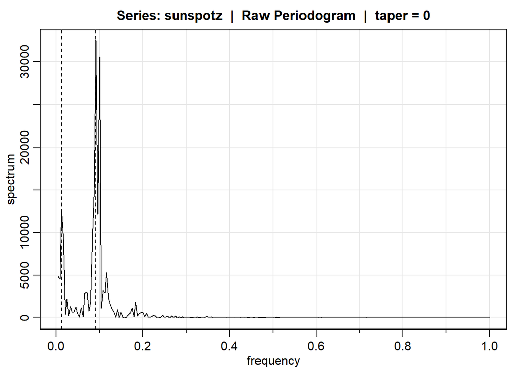

```r
mvspec(sunspotz, taper=0, log="no") # for CI, remove log="no"
abline(v=3/240, lty="dashed") # 80 year cycle
abline(v=22/240, lty="dashed") # 11 year cycle
```

```r
#par(mfrow=c(2,1))
#mvspec(saltemp, spans=c(1,1), log="no", taper=.5)
#abline(v=1/16, lty="dashed")
#salt.per = mvspec(salt, spans=c(1,1), log="no", taper=.5)
#abline(v=1/16, lty="dashed")
```